# Thực hành Ứng dụng Numpy

```python
plt.draw()
```

```python
plt.close("all")
```

```python
xarr = np.array([1.1, 1.2, 1.3, 1.4, 1.5])
yarr = np.array([2.1, 2.2, 2.3, 2.4, 2.5])
cond = np.array([True, False, True, True, False])
```

```python
result = [(x if c else y)
          for x, y, c in zip(xarr, yarr, cond)]
result
```

```
[np.float64(1.1),
 np.float64(2.2),
 np.float64(1.3),
 np.float64(1.4),
 np.float64(2.5)]
```

```python
result = np.where(cond, xarr, yarr)
result
```

```
array([1.1, 2.2, 1.3, 1.4, 2.5])
```

```python
arr = rng.standard_normal((4, 4))
arr
arr > 0
np.where(arr > 0, 2, -2)
```

```
array([[ 2,  2,  2, -2],
       [-2, -2,  2,  2],
       [-2, -2,  2,  2],
       [-2,  2, -2, -2]])
```

```python
np.where(arr > 0, 2, arr) # set only positive values to 2
```

```
array([[ 2.    ,  2.    ,  2.    , -0.959 ],
       [-1.2094, -1.4123,  2.    ,  2.    ],
       [-0.6588, -1.2287,  2.    ,  2.    ],
       [-0.1308,  2.    , -0.093 , -0.0662]])
```

```python
arr = rng.standard_normal((5, 4))
arr
arr.mean()
np.mean(arr)
arr.sum()
```

```
np.float64(-1.743948891486906)
```

```python
arr.mean(axis=1)
arr.sum(axis=0)
```

```
array([-1.6292,  1.0399, -0.3344, -0.8203])
```

```python
arr = np.array([0, 1, 2, 3, 4, 5, 6, 7])
arr.cumsum()
```

```
array([ 0,  1,  3,  6, 10, 15, 21, 28])
```

```python
arr = np.array([[0, 1, 2], [3, 4, 5], [6, 7, 8]])
arr
```

```
array([[0, 1, 2],
       [3, 4, 5],
       [6, 7, 8]])
```

```python
arr.cumsum(axis=0)
arr.cumsum(axis=1)
```

```
array([[ 0,  1,  3],
       [ 3,  7, 12],
       [ 6, 13, 21]])
```

```python
arr = rng.standard_normal(100)
(arr > 0).sum() # Number of positive values
(arr <= 0).sum() # Number of non-positive values
```

```
np.int64(52)
```

```python
bools = np.array([False, False, True, False])
bools.any()
bools.all()
```

```
np.False_
```

```python
arr = rng.standard_normal(6)
arr
arr.sort()
arr
```

```
array([-0.7208, -0.6839, -0.0824, -0.0548,  0.0773,  1.1206])
```

```python
arr = rng.standard_normal((5, 3))
arr
```

```
array([[ 0.936 ,  1.2385,  1.2728],
       [ 0.4059, -0.0503,  0.2893],
       [ 0.1793,  1.3975,  0.292 ],
       [ 0.6384, -0.0279,  1.3711],
       [-2.0528,  0.3805,  0.7554]])
```

```python
arr.sort(axis=0)
arr
arr.sort(axis=1)
arr
```

```
array([[-2.0528, -0.0503,  0.2893],
       [-0.0279,  0.1793,  0.292 ],
       [ 0.3805,  0.4059,  0.7554],
       [ 0.6384,  1.2385,  1.2728],
       [ 0.936 ,  1.3711,  1.3975]])
```

```python
arr2 = np.array([5, -10, 7, 1, 0, -3])
sorted_arr2 = np.sort(arr2)
sorted_arr2
```

```
array([-10,  -3,   0,   1,   5,   7])
```

```python
names = np.array(["Bob", "Will", "Joe", "Bob", "Will", "Joe", "Joe"])
np.unique(names)
ints = np.array([3, 3, 3, 2, 2, 1, 1, 4, 4])
np.unique(ints)
```

```
array([1, 2, 3, 4])
```

```python
sorted(set(names))
```

```
[np.str_('Bob'), np.str_('Joe'), np.str_('Will')]
```

```python
values = np.array([6, 0, 0, 3, 2, 5, 6])
np.in1d(values, [2, 3, 6])
```

```
array([ True, False, False,  True,  True, False,  True])
```

```python
arr = np.arange(10)
np.save("some_array", arr)
```

```python
np.load("some_array.npy")
```

```
array([0, 1, 2, 3, 4, 5, 6, 7, 8, 9])
```

```python
np.savez("array_archive.npz", a=arr, b=arr)
```

```python
arch = np.load("array_archive.npz")
arch["b"]
```

```
array([0, 1, 2, 3, 4, 5, 6, 7, 8, 9])
```

```python
np.savez_compressed("arrays_compressed.npz", a=arr, b=arr)
```

```python
!rm some_array.npy
!rm array_archive.npz
!rm arrays_compressed.npz
```

```python
x = np.array([[1., 2., 3.], [4., 5., 6.]])
y = np.array([[6., 23.], [-1, 7], [8, 9]])
x
y
x.dot(y)
```

```
array([[ 28.,  64.],
       [ 67., 181.]])
```

```python
np.dot(x, y)
```

```
array([[ 28.,  64.],
       [ 67., 181.]])
```

```python
x @ np.ones(3)
```

```
array([ 6., 15.])
```

```python
from numpy.linalg import inv, qr
X = rng.standard_normal((5, 5))
mat = X.T @ X
inv(mat)
mat @ inv(mat)
```

```
array([[ 1.,  0., -0.,  0., -0.],
       [ 0.,  1.,  0.,  0., -0.],
       [ 0., -0.,  1., -0., -0.],
       [ 0., -0.,  0.,  1., -0.],
       [ 0., -0.,  0., -0.,  1.]])
```

```python
import random
position = 0
walk = [position]
nsteps = 1000
for _ in range(nsteps):
    step = 1 if random.randint(0, 1) else -1
    position += step
    walk.append(position)
```

Mô phỏng **chuyển động ngẫu nhiên một chiều (1D random walk)** trong 1000 bước.

- `position = 0`: bắt đầu tại vị trí gốc (0).
- `walk = [position]`: danh sách lưu lại toàn bộ vị trí sau mỗi bước.
- Vòng lặp `for _ in range(nsteps)` chạy 1000 lần, mỗi lần:
  - `step = 1 if random.randint(0, 1) else -1`: chọn ngẫu nhiên bước tiến (+1) hoặc lùi (-1).
  - `position += step`: cập nhật vị trí hiện tại.
  - `walk.append(position)`: lưu vị trí vào danh sách.

→ Kết quả là một chuỗi các vị trí biểu diễn **quỹ đạo chuyển động ngẫu nhiên** theo thời gian.

```python
plt.figure()
```

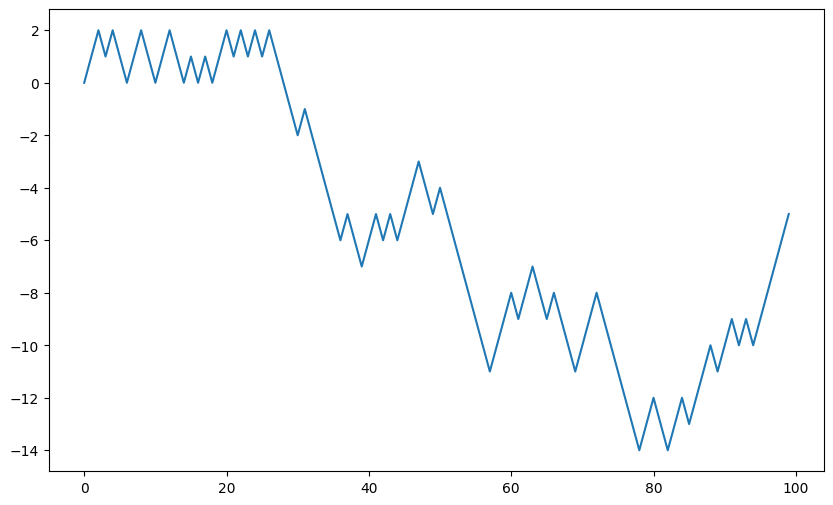

```python
plt.plot(walk[:100])
```

Vẽ **đồ thị chuyển động ngẫu nhiên trong 100 bước đầu tiên** của danh sách `walk`.

- Trục X biểu thị **số bước di chuyển (từ 0 đến 99)**.
- Trục Y biểu thị **vị trí tương ứng sau mỗi bước**.  
  → Biểu đồ giúp quan sát xu hướng dao động của quá trình ngẫu nhiên trong giai đoạn đầu.

```python
nsteps = 1000
rng = np.random.default_rng(seed=12345)  # fresh random generator
draws = rng.integers(0, 2, size=nsteps)
steps = np.where(draws == 0, 1, -1)
walk = steps.cumsum()
```

```python
walk.min()
walk.max()
```

```
np.int64(50)
```

```python
(np.abs(walk) >= 10).argmax()
```

```
np.int64(155)
```

```python
nwalks = 5000
nsteps = 1000
draws = rng.integers(0, 2, size=(nwalks, nsteps)) # 0 or 1
steps = np.where(draws > 0, 1, -1)
walks = steps.cumsum(axis=1)
walks
```

```
array([[  1,   2,   3, ...,  22,  23,  22],
       [  1,   0,  -1, ..., -50, -49, -48],
       [  1,   2,   3, ...,  50,  49,  48],
       ...,
       [ -1,  -2,  -1, ..., -10,  -9, -10],
       [ -1,  -2,  -3, ...,   8,   9,   8],
       [ -1,   0,   1, ...,  -4,  -3,  -2]])
```

```python
walks.max()
walks.min()
```

```
np.int64(-120)
```

```python
hits30 = (np.abs(walks) >= 30).any(axis=1)
hits30
hits30.sum() # Number that hit 30 or -30
```

```
np.int64(3395)
```

```python
crossing_times = (np.abs(walks[hits30]) >= 30).argmax(axis=1)
crossing_times
```

```
array([201, 491, 283, ..., 219, 259, 541])
```

```python
crossing_times.mean()
```

```
np.float64(500.5699558173785)
```

```python
draws = 0.25 * rng.standard_normal((nwalks, nsteps))
```